# PA1_template

# “Reproducible Research: Peer Assessment 1”

## Load required libraries

```r
library(ggplot2)
library(lattice)
```

## Loading and preprocessing the data

```r
file="C:/Users/Nicholas/Downloads/repdata%2Fdata%2Factivity/activity.csv"
activity<-read.csv(file, header = TRUE, colClass=c('integer', 'Date', 'integer'))
```

## Learn about the data.

```r
str(activity)
head(activity)
summary(activity)
```

[output not shown]

## What is mean total number of steps taken per day?

In this section we will sum up the steps by day using the **aggregate** function.

```r
daytotal<-aggregate(steps ~ date, activity, sum)
```

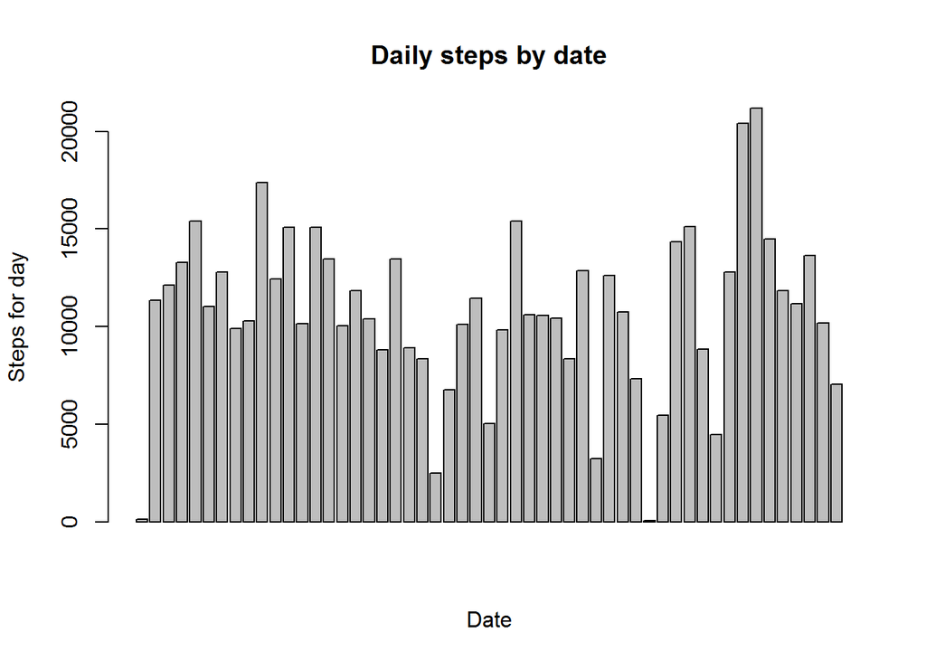

```r
barplot(daytotal$steps,xlab="Date",ylab="Steps for day",main="Daily steps by date")
```

Next let us compare the mean vs the median of the total number of steps taken per day.

```r
mean(daytotal$steps)
```

```
## [1] 10766.19
```

```r
median(daytotal$steps)
```

```
## [1] 10765
```

## What is the average daily activity pattern?

When making this graph we will no longer be looking at the daily amount and now in 5 minute intervals (the intervals given)

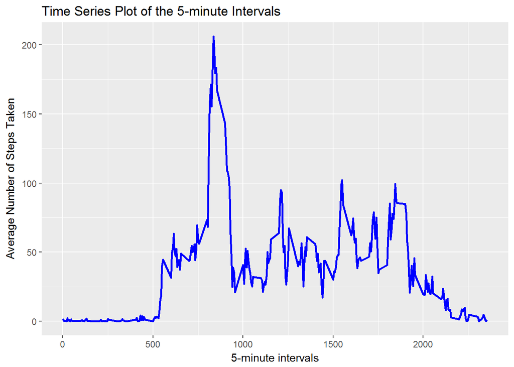

```r
interval.total<-aggregate(steps ~ interval, activity, mean)
ggplot(interval.total,aes(interval,steps))+geom_line(color="blue",size=1)+labs(title = "Time Series Plot of the 5-minute Intervals", x = "5-minute intervals", y = "Average Number of Steps Taken")
```

## The 5-minute interval that, on average, contains the maximum number of steps

```r
max<-which.max(interval.total$steps)
interval.total$interval[max]
```

```
## [1] 835
```

## Imputing missing values

The total number of rows with with *NA*s is.

```r
sum(is.na(activity$steps))
```

```
## [1] 2304
```

## Fill in missing NA with the average number of steps in the same 5-min interval.

Create a new dataset `activity2` as the original and then replace the *NA* values. In this case we will be using the average for that interval.

```r
activity2 <- activity
for (i in interval.total$interval) {
  activity2[activity2$interval == i & is.na(activity2$steps), ]$steps <-
    interval.total$steps[interval.total$interval == i]
}
```